# UCI Repository: Heart Disease Data Set

# Introduction

The [UC Irvine Machine Learning Repository](https://archive.ics.uci.edu/ml/index.php) has a [heart disease data set](https://archive.ics.uci.edu/ml/datasets/Heart+Disease) based on four databases. The databases are located in Cleveland, Hungary, Switzerland, and the Long Beach VA.

As of January 20, 2020, the Cleveland data has received the [second highest number of votes on Kaggle](https://www.kaggle.com/datasets?sort=votes). However, a [discussion post](https://www.kaggle.com/ronitf/heart-disease-uci/discussion/105877) addresses some issues concerning the integrity of the Kaggle data.

The purpose of this document is to obtain all of the data available on the UCI website, clean it, and compare the UCI Cleveland data with the data on Kaggle. With any luck, we will end up with a data set that is richer and more reliable than the one on Kaggle.

# Import

The data may be downloaded [here](https://archive.ics.uci.edu/ml/machine-learning-databases/heart-disease/). We will be using the following files:

- `processed.cleveland.data`
- `processed.hungarian.data`
- `processed.switzerland.data`
- `processed.va.data`

We will use the `tidyverse` library to help with our data wrangling.

```r
library(tidyverse)
cleveland <- read_csv("../Data/processed.cleveland.data",
                      col_names = FALSE,
                      col_types = cols())
switzerland <- read_csv("../Data/processed.switzerland.data",
                        col_names = FALSE,
                        col_types = cols())
va <- read_csv("../Data/processed.va.data",
               col_names = FALSE,
               col_types = cols())
hungarian <- read_csv("../Data/processed.hungarian.data",
                      col_names = FALSE,
                      col_types = cols())
```

# Clean

The data we have downloaded is unlabeled.

```r
cleveland %>% slice(1:5)
```

```
## # A tibble: 5 x 14
##      X1    X2    X3    X4    X5    X6    X7    X8    X9   X10   X11 X12
##   <dbl> <dbl> <dbl> <dbl> <dbl> <dbl> <dbl> <dbl> <dbl> <dbl> <dbl> <chr>
## 1    63     1     1   145   233     1     2   150     0   2.3     3 0.0
## 2    67     1     4   160   286     0     2   108     1   1.5     2 3.0
## 3    67     1     4   120   229     0     2   129     1   2.6     2 2.0
## 4    37     1     3   130   250     0     0   187     0   3.5     3 0.0
## 5    41     0     2   130   204     0     2   172     0   1.4     1 0.0
## # ... with 2 more variables: X13 <chr>, X14 <dbl>
```

We will use the [data dictionary](https://archive.ics.uci.edu/ml/datasets/Heart+Disease) to label the data. To assist with the process, we will write a function. What does this function do? After naming the variables, it replaces all question marks (missing values) with `NA`s. Then it applies labels for the values of several variables.

```r
 clean_data <- function(data){
  data %>%
    rename(age = X1, sex = X2, cp = X3, trestbps = X4, chol = X5,
           fbs = X6, restecg = X7, thalach = X8, exang = X9, oldpeak = X10,
           slope = X11, ca = X12, thal = X13, num = X14) %>%
    replace_with_na_all(condition = ~.x == "?")  %>%
    mutate_if(is.character, ~ as.numeric(.x)) %>%
    mutate(sex = factor(sex)) %>%
    mutate(sex = fct_recode(sex, "Female" = "0", "Male" = "1")) %>%
    mutate(cp = factor(cp)) %>%
    mutate(cp = fct_recode(cp,
                           "Typical Angina" = "1",
                           "Atypical Angina" = "2",
                           "Non-Anginal Pain" = "3",
                           "Asymptomatic" = "4"
    )) %>%
    mutate(fbs = factor(fbs)) %>%
    mutate(fbs = fct_recode(fbs, ">120 mg/dl" = "1", "<120 mg/dl" = "0")) %>%
    mutate(restecg = factor(restecg)) %>%
    mutate(restecg = fct_recode(restecg,
                                "Normal" = "0",
                                "ST-T Wave Abnormality" = "1",
                                "Probable or Defininte LVH" = "2"
    )) %>%
    mutate(exang = factor(exang)) %>%
    mutate(exang = fct_recode(exang, "EIA" = "1", "Non-EIA" = "0")) %>%
    mutate(slope = factor(slope)) %>%
    mutate(slope = fct_recode(slope,
                              "Up" = "1",
                              "Flat" = "2",
                              "Down" = "3")) %>%
    mutate(thal = factor(thal)) %>%
    mutate(thal = fct_recode(thal,
                             "Normal" = "3",
                             "Fixed Defect" = "6",
                             "Reversable Defect" = "7"))
}
```

Let’s test out our function. Note that we have used one command, `replace_with_na_all`, which utilized the `naniar` library.

```r
library(naniar)
clean_cleveland <- cleveland %>% clean_data() %>% mutate(source = "Cleveland")
clean_switzerland <- switzerland %>% clean_data() %>% mutate(source = "Switzerland")
clean_hungarian <- hungarian %>% clean_data() %>% mutate(source = "Hungarian")
clean_va <- va %>% clean_data() %>% mutate(source = "VA")

clean_cleveland %>% slice(1:5)
```

```
## # A tibble: 5 x 15
##     age sex   cp    trestbps  chol fbs   restecg thalach exang oldpeak
##   <dbl> <fct> <fct>    <dbl> <dbl> <fct> <fct>     <dbl> <fct>   <dbl>
## 1    63 Male  Typi~      145   233 >120~ Probab~     150 Non-~     2.3
## 2    67 Male  Asym~      160   286 <120~ Probab~     108 EIA       1.5
## 3    67 Male  Asym~      120   229 <120~ Probab~     129 EIA       2.6
## 4    37 Male  Non-~      130   250 <120~ Normal      187 Non-~     3.5
## 5    41 Fema~ Atyp~      130   204 <120~ Probab~     172 Non-~     1.4
## # ... with 5 more variables: slope <fct>, ca <dbl>, thal <fct>, num <dbl>,
## #   source <chr>
```

# Verify

We will combine our clean data into a single data frame.

```r
combined_dat <- bind_rows(clean_cleveland, clean_switzerland, clean_hungarian, clean_va)
```

The [data dictionary from UCI](https://archive.ics.uci.edu/ml/datasets/Heart+Disease) informs us that the outcome variable `num`

> refers to the presence of heart disease in the patient. It is integer valued from 0 (no presence) to 4. Experiments with the Cleveland database have concentrated on simply attempting to distinguish presence (values 1,2,3,4) from absence (value 0).

Let’s investigate this.

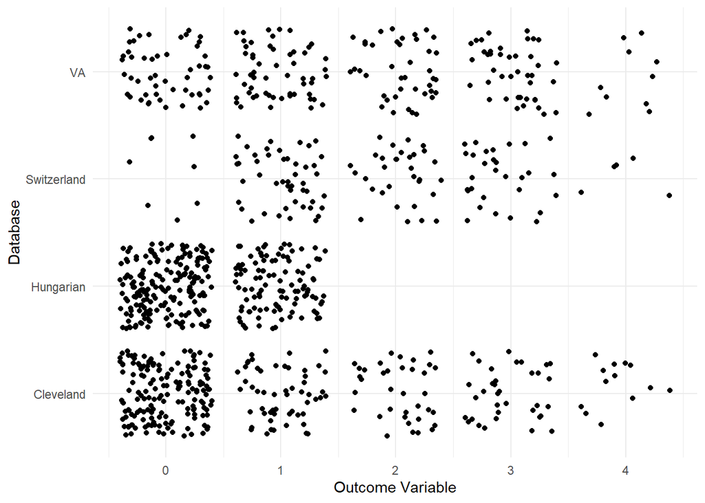

```r
combined_dat %>%
  ggplot(mapping = aes(x = num, y = source)) +
  geom_jitter() +
  labs(x = "Outcome Variable", y = "Database") +
  theme_minimal()
```

Interestingly, we see that it is the Hungarian database, not the Cleveland one, that has used a binary classification.

We will create binary classifications for all of our data and call the results `num2`, but we will keep the multinomial classifications for Cleveland, Switzerland, and the VA, and store them in `num5`.

```r
dat <-
  combined_dat %>%
  mutate(num2 = as.numeric(num > 0)) %>%
  mutate(num5 = if_else(source != "Hungarian", num, -999)) %>%
  mutate(num5 = na_if(num5, -999))
```

We check the multinomial outcome…

```r
dat %>% group_by(source, num5) %>% tally()%>% spread(num5, n)
```

```
## # A tibble: 4 x 7
## # Groups:   source [4]
##   source        `0`   `1`   `2`   `3`   `4` `<NA>`
##   <chr>       <int> <int> <int> <int> <int>  <int>
## 1 Cleveland     164    55    36    35    13     NA
## 2 Hungarian      NA    NA    NA    NA    NA    294
## 3 Switzerland     8    48    32    30     5     NA
## 4 VA             51    56    41    42    10     NA
```

and the binary outcome.

```r
dat %>% group_by(source, num2) %>% tally()%>% spread(num2, n)
```

```
## # A tibble: 4 x 3
## # Groups:   source [4]
##   source        `0`   `1`
##   <chr>       <int> <int>
## 1 Cleveland     164   139
## 2 Hungarian     188   106
## 3 Switzerland     8   115
## 4 VA             51   149
```

# Explore

One point addressed in [the forementioned Kaggle post](https://www.kaggle.com/ronitf/heart-disease-uci/discussion/105877) is that the outcome variable (which is called `target` in the Kaggle data set) is labeled so that `0` indicates presence of heart disease, while `1` indicates absence of heart disease. Indeed, when we compare the Kaggle outcomes with the UCI Cleveland Data, this appears to be the case.

```r
kaggle_dat <- read_csv("../Data/heart.csv", col_types = cols())
kaggle_dat %>% group_by(target) %>% tally() %>% spread(target, n)
```

```
## # A tibble: 1 x 2
##     `0`   `1`
##   <int> <int>
## 1   138   165
```

## Cholesterol and Switzerland

After checking the integrity of our data, it appears as though some missing values for the erum cholestoral variable (`chol`) were entered as zero.

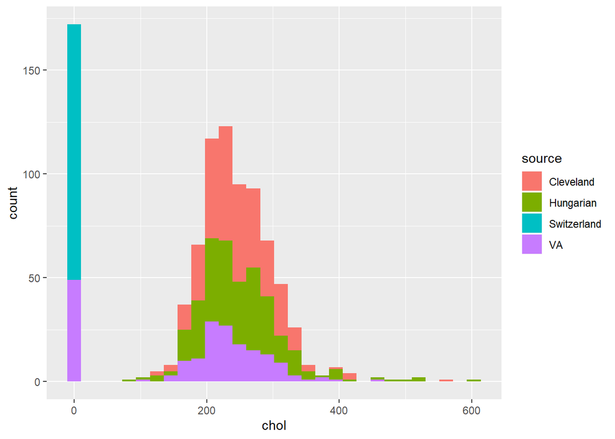

```r
dat %>% ggplot(mapping = aes(x = chol, fill = source)) + geom_histogram()
```

Let’s fix this.

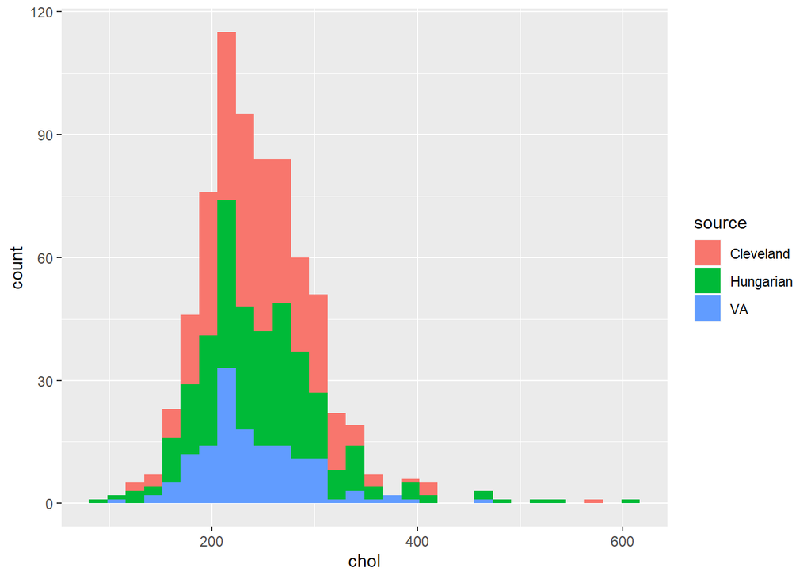

```r
dat <- dat %>% mutate(chol = na_if(chol, 0))
dat %>% ggplot(mapping = aes(x = chol, fill = source)) + geom_histogram()
```

## Missing Data

We see that the Cleveland data is mostly “complete” with respect to our variables of interest. Meanwhile the data from the other sources suffers from missingness.

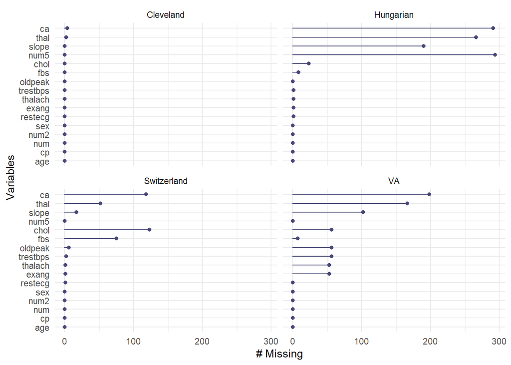

```r
gg_miss_var(dat, facet = source)
```

# Conclusion

We can see why the Cleveland database was used on Kaggle, as it was the most complete database. Nevertheless, if you are interested in using the complete data set, you may find it [here](https://github.com/jameshenegan/data/tree/master/uciHeart).